# STAT 201 - Statistical Inference for Data Science

## Lecture 7: Confidence Intervals (of means and proportions) based on the assumption of Normality or the Central Limit Theorem

**Attribution:** these slides are adapted from [Rodolfo Lourenzutti's slides](https://github.com/UBC-STAT/stat-201/blob/website/lec/stat201-week7.pdf)

## Reminders

- **Midterm 2 - Thursday Aug 3**
  - covers all the material from modules 6, 7, 8 (however, the content is cumulative as the concepts are dependent)
- Please email me if it shows 0 in the canvas grade book for homework/tutorial even though you completed before the due date

- Project Proposal due Jul 30 - Instructions under "Deliverable 2: Project Proposal" on the [course website](https://ubc-stat.github.io/stat-201/group-project.html)

## Re-cap

#### Module 1 - Introduction to Statistical Inference and Sampling

- Understand the terminologies in statistical inferene (Population, Sample, Sampling, Point estimate (sample statistics), Sample distribution, Sampling distribution, Standard error)

#### Module 2 - Populations and Sampling

- Sampling methodology, Sampling distribution

#### Module 3 - Bootstrapping and its Relationship to the Sampling Distribution

- Bootstrap distribution

#### Module 4 - Confidence Intervals via bootstrapping

- Bootstrap confidence interval

#### Module 5 - Midterm 1

#### Module 6 - Hypothesis Testing via simulation/randomization

## Statistical Inference

1. **Point estimation**: we estimate an unknown parameter using a *single number* calculated from sample data.
2. **Interval estimation**: we estimate an unknown parameter using an *interval of values* that plausibly contain the true parameter value (and state how confident we are the interval captures the true value).
3. **Hypothesis testing**: we make a statement about the value of an unknown population parameter, and we check whether or not the data obtained from the sample provide evidence against this claim.

## Review: Bootstrapping

[figure not shown]

*image source: [Towards Data Science](https://towardsdatascience.com/bootstrapping-statistics-what-it-is-and-why-its-used-e2fa29577307)*

## Today: Traditional methods

[figure not shown]

*image source: [Towards Data Science](https://towardsdatascience.com/bootstrapping-statistics-what-it-is-and-why-its-used-e2fa29577307)*

## Sampling Scenarios

[output not shown]

[output not shown]

TABLE 7.5: Scenarios of sampling for inference from [Modern Dive](https://moderndive.com/7-sampling.html#sampling-conclusion-central-limit-theorem) by Kim & McConville

## Normal (Gaussian) distribution

A distribution defined by two values:

1. the mean $\mu$ ("mu") and
2. the standard deviation $\sigma$ ("sigma")

A normal distribution is:

- Unimodal (one peak) and bell-shaped;
- Symmetric around the mean, $\mu$

[figure not shown]

```r
IRdisplay::display_html('<iframe src="https://www.zoology.ubc.ca/~whitlock/Kingfisher/SamplingNormal.htm" width=1000, height=550iframe>')
```

## Location & spread

- The mean $\mu$ controls the location of the center of the distribution
- The standard deviation $\sigma$, controls the spread of the curve (wider or narrower)
- We give a normal distribution with a mean $\mu = 0$ and the standard deviation $\sigma = 1$ a special name. It's called the **standard normal distribution**.

[figure not shown]

## 68-95-99.7% rule (Empirical rule)

If a variable follows a Normal distribution, there are three rules of thumb we can use:

- approximately 68% of values will lie within $\pm1$ standard deviation of the mean
- approximately 95% of values will lie within $\pm2$ standard deviation of the mean
- approximately 99.7% of values will lie within $\pm3$ standard deviation of the mean

[figure not shown]

*image source: [Andymath.com](https://andymath.com/normal-distribution-empirical-rule/)*

## Functions in R for the Normal distribution

- We can use software packages to get the desired probability or quantiles.
- Probabilities: e.g., $P(X \le 0)$

> pnorm(0, mu, sigma)
- Quantiles: e.g., $P(X \le x) = 0.25$

> qnorm(0.25, mu, sigma)

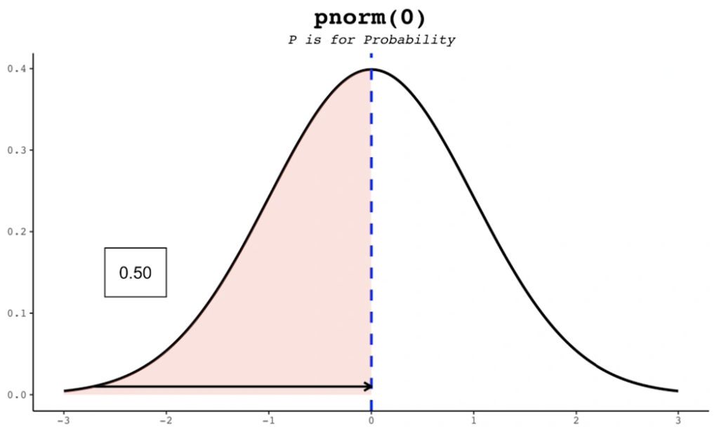

[figure not shown]

*image source: [Visual guide to pnorm, dnorm, qnorm, and rnorm functions in R](https://diggingdeeperwithstats.wordpress.com/2021/05/21/visual-guide-to-pnorm-dnorm-qnorm-and-rnorm-functions-in-r/)*

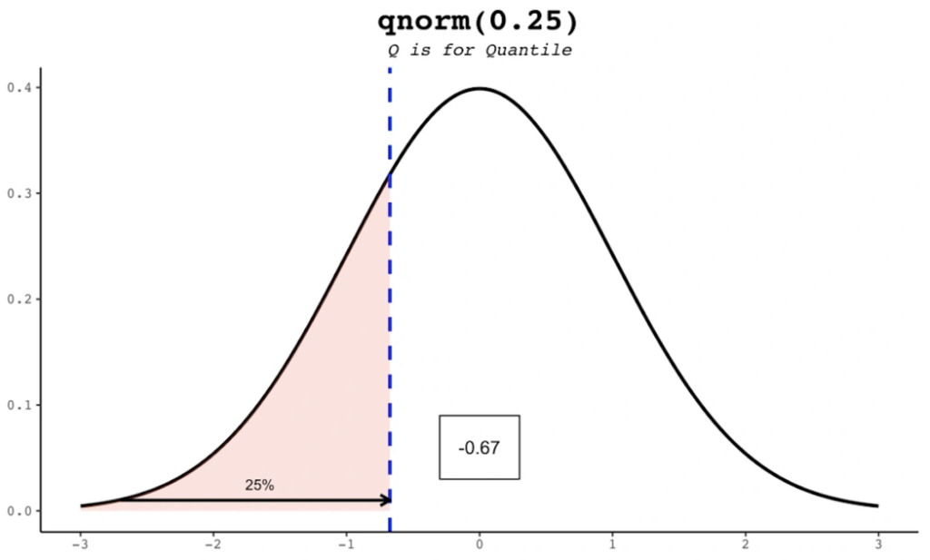

```
pnorm(0)
pnorm(-2, 0, 1)
qnorm(0.84)
```

## Clicker Question 1

Suppose the lengths of fish in a certain lake follow approximately a Normal distribution with mean $\mu = 100$ mm and standard deviation $\sigma = 10$ mm.

Approximately, what percentage of fish have lengths below 90 mm? (Use the 68-95-99.7 rule)

A. 2.5%

B. 5%

C. 16%

D. 68%

```r
pnorm(..., mean = ..., sd = ...)
```

```r
pnorm(90, mean = 100, sd = 10)
```

C

## Clicker Question 2

Suppose the lengths of fish in a certain lake follow approximately a Normal distribution with mean $\mu = 100$ mm and standard deviation $\sigma = 10$ mm.

How big is the length such that only 2.5% of fish fall above?

A. 100 mm

B. 110 mm

C. 120 mm

D. 130 mm

```r
qnorm(..., mean = 100, sd = 10)
```

```r
qnorm(.975, mean = 100, sd = 10)
```

## Recall: Sampling Distributions of Proportions

The sampling distribution of proportions is the distribution of the sample proportions of all possible random samples of size $n$ that can be obtained from a population.

For sufficiently large samples (such that $n\times p\ge 10$ and $n \times (1-p)\ge 10$) and with other necessary conditions, the sampling distribution of $\hat{p}$ is approximately Normal with

- with mean $p$ and
- standard error $\sqrt{\frac{p \times (1-p)}{n}}$

The larger the sample size n, the better the normal approximation.

## Recall: Sampling Distribution of Means

The sampling distribution of means is the distribution of the means of all the possible random samples of size $n$ that could be selected from a population.

Let $x_1, x_2, ..., x_n$ be independent values of a random sample from some population with mean $\mu$ and standard deviation $\sigma$. The Central Limit Theorem (CLT) states that for large sample sizes ($n$) the sampling distribution of the sample mean is approximately Normally distributed, regardless of the distribution of the population one samples from with

- mean $\mu$ and
- standard error $\frac{\sigma}{\sqrt{n}}$

Note: If the population distribution is Normal, the sample mean $\bar{X}$ follows the Normal model with mean $\mu$ and standard deviation $\frac{\sigma}{\sqrt{n}}$ regardless of the sample size.

## Central Limit Theorem - Explain using an applet

```r
IRdisplay::display_html('<iframe src="https://www.zoology.ubc.ca/~whitlock/Kingfisher/CLT.htm" width=800, height=550iframe>')
```

## Assumptions & conditions

- The sample is randomly drawn from the population.
- The sample values are independent. In general, if your sample size is greater than 10% of the population size, there will be a severe violation of independence.
- The sample size must be large enough.
  - For proportions:
    - check $n\times p \ge 10$ and $n\times(1-p) \ge 10$.
  - For means:
    - there is no universal guideline, and we might need a large sample size. Usually, however, sample sizes larger than 30 are enough to get a reasonable approximation (but it is not guaranteed).

## Recall

The **standard error** is the standard deviation of point estimates

$$\sigma_{\hat{p}} = \sqrt{\frac{p(1-p)}{n}}$$

- $\sigma_{\hat{p}}$: standard deviation of sample proportions (i.e. standard error)
- $p$: population proportion

$$\sigma_{\bar{x}} = \frac{\sigma}{\sqrt{n}}$$

- $\sigma_{\bar{x}}$: standard deviation of sample mean (i.e. standard error)
- $\sigma$: standard deviation of population

### In reality:

- We don't know the value of the population proportion ($p$) so we estimate $p$ using the sample proportion ($\hat{p}$). Thus we estimate $\sigma_{\hat{p}}$ (variability of $\hat{p}$) using:

$$\sigma_{\hat{p}} = \sqrt{\frac{\hat{p} \times (1-\hat{p})}{n}}$$

- We don't know the value of the population standard deviation ($\sigma$) so we estimate $\sigma$ using the sample standard deviation ($s$). Thus we estimate $\sigma_{\bar{x}}$ using

$$\sigma_{\bar{X}} = \frac{s}{\sqrt{n}}$$

## Idea behind confidence intervals

- By the 68-95-99.7 rule, approximately 95% of $\hat{p}$ will fall between $p \pm 2 \times \sigma_{\hat{p}}$

[figure not shown]

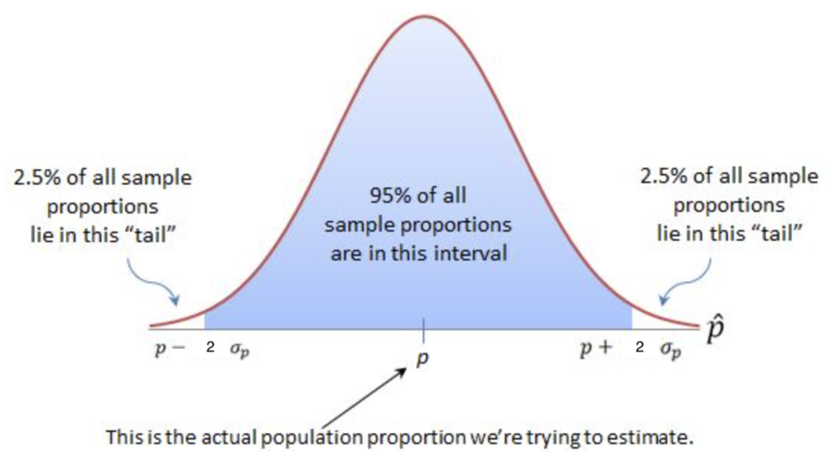

## Confidence Intervals

Today the confidence intervals for population parameters we will be learning about today take the following form:

statistic $\pm$ margin of error

statistic $\pm$ critical value $\times$ standard error

## Confidence Intervals: proportions

Formula for a confidence interval (CI) for the population proportion $p$:

$$\hat{p} \pm z^* \times \sigma_{\hat{p}}$$$$\hat{p} \pm z^* \times \sqrt{\frac{\hat{p}(1 - \hat{p})}{n}}$$

where $z^∗$ is called the critical value.

## Finding the critical value

- The critical value depends on the confidence level you choose
- $z^∗$ is the value such that the upper tail area (area to the right of $z^*$) under the standard normal curve equals to $\frac{1 - C}{2}$ (where $C$ is the confidence level).

[figure not shown]

## Finding $z^*$ in R

Recall:

- Quantiles: e.g., $P(X \le x) = 0.25$

> qnorm(0.25, mu, sigma)

For a 95% confidence level, the $z^*$ is...

```r
qnorm(...)
```

```
Error in eval(expr, envir, enclos): '...' used in an incorrect context
Traceback:
```

```r
qnorm(0.975)
```

## Confidence Intervals: means

Formula for a confidence interval (CI) for the population mean $\mu$:

$$\bar{x} \pm z^* \times \sigma_{\bar{x}}$$$$\bar{x} \pm z^* \times \frac{s}{\sqrt{n}}$$

where $z^∗$ is the z-score such that upper tail area under the standard Normal curve is equal to $\frac{1 - C}{2}$ (where $C$ is the confidence level).

*Note: we could actually get a better approximation using the t-distribution, which we will learn about in the next module. However, for large $n$, the Normal and $t$ distributions are quite close*

## Assumptions & conditions for constructing confidence intervals

- The sample is randomly drawn from the population.
- The sample values are independent. In general, if your sample size is greater than 10% of the population size, there will be a severe violation of independence.
- The sample size must be large enough.
  - For proportions: Check $n\times \hat{p} \ge 10$ and $n\times(1-\hat{p}) \ge 10$ (Remember we don't know $p$!)
  - For means: Usually, sample sizes larger than 30 are enough to get a reasonable approximation (but it is not guaranteed).

## Clicker question 3

A manufacturer is producing a chocolate bar. The factory manager wants to find out about the true proportion of the bars that are overweight (i.e. the weight is larger than the labeled weight). They take a random sample of 100 bars and find that 20 out of 100 are overweight.

A 95% confidence interval for the true proportion of the bars that are overweight is:

A. $0.20 \pm 0.04$

B. $0.20 \pm 0.08$

C. $100 \pm 0.04$

D. $100 \pm 0.08$

## Confidence interval interpretation

```r
IRdisplay::display_html('<iframe src="https://www.zoology.ubc.ca/~whitlock/Kingfisher/CIMean.htm" width=800, height=550iframe>')
```

## Get started on worksheet 7!

- Navigate to Canvas, open `worksheet_07`

If you get stuck:

- Discuss with your neighbours, the TAs & Instructors, and consult the textbook reading to help you get unstuck when needed!
- Ask your group mates if you need help with any questions
- The TAs and myself will walk around and answer questions

## What did you learn today?

## Take a break!

Come back at 3:00 PM